# Risk Factor Analysis

## Outcome Variable

**Outcome Variable:** sstunted

## Predictor Variables

**Intervention Variable:** brthmon

**Adjustment Set:**

unadjusted

## Stratifying Variables

The analysis was stratified on these variable(s):

- agecat
- studyid
- country

## Data Summary

| agecat | studyid | country | A | n | nA | nAY0 | nAY1 |
| --- | --- | --- | --- | --- | --- | --- | --- |
| Birth | ki0047075b-MAL-ED | BANGLADESH | 1 | 257 | 20 | 20 | 0 |
| Birth | ki0047075b-MAL-ED | BANGLADESH | 2 | 257 | 25 | 24 | 1 |
| Birth | ki0047075b-MAL-ED | BANGLADESH | 3 | 257 | 25 | 25 | 0 |
| Birth | ki0047075b-MAL-ED | BANGLADESH | 4 | 257 | 21 | 21 | 0 |
| Birth | ki0047075b-MAL-ED | BANGLADESH | 5 | 257 | 21 | 19 | 2 |
| Birth | ki0047075b-MAL-ED | BANGLADESH | 6 | 257 | 11 | 11 | 0 |
| Birth | ki0047075b-MAL-ED | BANGLADESH | 7 | 257 | 20 | 19 | 1 |
| Birth | ki0047075b-MAL-ED | BANGLADESH | 8 | 257 | 26 | 23 | 3 |
| Birth | ki0047075b-MAL-ED | BANGLADESH | 9 | 257 | 21 | 20 | 1 |
| Birth | ki0047075b-MAL-ED | BANGLADESH | 10 | 257 | 25 | 25 | 0 |
| Birth | ki0047075b-MAL-ED | BANGLADESH | 11 | 257 | 15 | 15 | 0 |
| Birth | ki0047075b-MAL-ED | BANGLADESH | 12 | 257 | 27 | 26 | 1 |
| Birth | ki0047075b-MAL-ED | BRAZIL | 1 | 191 | 11 | 10 | 1 |
| Birth | ki0047075b-MAL-ED | BRAZIL | 2 | 191 | 19 | 18 | 1 |
| Birth | ki0047075b-MAL-ED | BRAZIL | 3 | 191 | 18 | 17 | 1 |
| Birth | ki0047075b-MAL-ED | BRAZIL | 4 | 191 | 9 | 9 | 0 |
| Birth | ki0047075b-MAL-ED | BRAZIL | 5 | 191 | 18 | 16 | 2 |
| Birth | ki0047075b-MAL-ED | BRAZIL | 6 | 191 | 8 | 8 | 0 |
| Birth | ki0047075b-MAL-ED | BRAZIL | 7 | 191 | 16 | 15 | 1 |
| Birth | ki0047075b-MAL-ED | BRAZIL | 8 | 191 | 18 | 18 | 0 |
| Birth | ki0047075b-MAL-ED | BRAZIL | 9 | 191 | 29 | 27 | 2 |
| Birth | ki0047075b-MAL-ED | BRAZIL | 10 | 191 | 17 | 17 | 0 |
| Birth | ki0047075b-MAL-ED | BRAZIL | 11 | 191 | 18 | 18 | 0 |
| Birth | ki0047075b-MAL-ED | BRAZIL | 12 | 191 | 10 | 10 | 0 |
| Birth | ki0047075b-MAL-ED | INDIA | 1 | 206 | 16 | 16 | 0 |
| Birth | ki0047075b-MAL-ED | INDIA | 2 | 206 | 16 | 16 | 0 |
| Birth | ki0047075b-MAL-ED | INDIA | 3 | 206 | 21 | 21 | 0 |
| Birth | ki0047075b-MAL-ED | INDIA | 4 | 206 | 14 | 13 | 1 |
| Birth | ki0047075b-MAL-ED | INDIA | 5 | 206 | 7 | 7 | 0 |
| Birth | ki0047075b-MAL-ED | INDIA | 6 | 206 | 18 | 18 | 0 |

[output cut: 2154 more lines]

The following strata were considered:

- agecat: 12 months, studyid: ki0047075b-MAL-ED, country: BANGLADESH
- agecat: 12 months, studyid: ki0047075b-MAL-ED, country: BRAZIL
- agecat: 12 months, studyid: ki0047075b-MAL-ED, country: INDIA
- agecat: 12 months, studyid: ki0047075b-MAL-ED, country: NEPAL
- agecat: 12 months, studyid: ki0047075b-MAL-ED, country: PERU
- agecat: 12 months, studyid: ki0047075b-MAL-ED, country: SOUTH AFRICA
- agecat: 12 months, studyid: ki0047075b-MAL-ED, country: TANZANIA, UNITED REPUBLIC OF
- agecat: 12 months, studyid: ki1000108-CMC-V-BCS-2002, country: INDIA
- agecat: 12 months, studyid: ki1000108-IRC, country: INDIA
- agecat: 12 months, studyid: ki1000109-EE, country: PAKISTAN
- agecat: 12 months, studyid: ki1000109-ResPak, country: PAKISTAN
- agecat: 12 months, studyid: ki1000304b-SAS-CompFeed, country: INDIA
- agecat: 12 months, studyid: ki1000304b-SAS-FoodSuppl, country: INDIA
- agecat: 12 months, studyid: ki1017093-NIH-Birth, country: BANGLADESH
- agecat: 12 months, studyid: ki1066203-TanzaniaChild2, country: TANZANIA, UNITED REPUBLIC OF
- agecat: 12 months, studyid: ki1101329-Keneba, country: GAMBIA
- agecat: 12 months, studyid: ki1112895-Guatemala BSC, country: GUATEMALA
- agecat: 12 months, studyid: ki1113344-GMS-Nepal, country: NEPAL
- agecat: 12 months, studyid: ki1114097-CMIN, country: BANGLADESH
- agecat: 12 months, studyid: ki1114097-CMIN, country: BRAZIL
- agecat: 12 months, studyid: ki1114097-CMIN, country: GUINEA-BISSAU
- agecat: 12 months, studyid: ki1114097-CMIN, country: PERU
- agecat: 12 months, studyid: ki1114097-CONTENT, country: PERU
- agecat: 12 months, studyid: ki1119695-PROBIT, country: BELARUS
- agecat: 12 months, studyid: ki1126311-ZVITAMBO, country: ZIMBABWE
- agecat: 12 months, studyid: ki1148112-LCNI-5, country: MALAWI
- agecat: 12 months, studyid: kiGH5241-JiVitA-3, country: BANGLADESH
- agecat: 12 months, studyid: kiGH5241-JiVitA-4, country: BANGLADESH
- agecat: 18 months, studyid: ki0047075b-MAL-ED, country: BANGLADESH
- agecat: 18 months, studyid: ki0047075b-MAL-ED, country: BRAZIL
- agecat: 18 months, studyid: ki0047075b-MAL-ED, country: INDIA
- agecat: 18 months, studyid: ki0047075b-MAL-ED, country: NEPAL
- agecat: 18 months, studyid: ki0047075b-MAL-ED, country: PERU
- agecat: 18 months, studyid: ki0047075b-MAL-ED, country: SOUTH AFRICA
- agecat: 18 months, studyid: ki0047075b-MAL-ED, country: TANZANIA, UNITED REPUBLIC OF
- agecat: 18 months, studyid: ki1000108-CMC-V-BCS-2002, country: INDIA
- agecat: 18 months, studyid: ki1000108-IRC, country: INDIA
- agecat: 18 months, studyid: ki1000109-EE, country: PAKISTAN
- agecat: 18 months, studyid: ki1000109-ResPak, country: PAKISTAN
- agecat: 18 months, studyid: ki1000304b-SAS-CompFeed, country: INDIA
- agecat: 18 months, studyid: ki1000304b-SAS-FoodSuppl, country: INDIA
- agecat: 18 months, studyid: ki1017093-NIH-Birth, country: BANGLADESH
- agecat: 18 months, studyid: ki1066203-TanzaniaChild2, country: TANZANIA, UNITED REPUBLIC OF
- agecat: 18 months, studyid: ki1101329-Keneba, country: GAMBIA
- agecat: 18 months, studyid: ki1112895-iLiNS-Zinc, country: BURKINA FASO
- agecat: 18 months, studyid: ki1113344-GMS-Nepal, country: NEPAL
- agecat: 18 months, studyid: ki1114097-CMIN, country: BANGLADESH
- agecat: 18 months, studyid: ki1114097-CMIN, country: BRAZIL
- agecat: 18 months, studyid: ki1114097-CMIN, country: GUINEA-BISSAU
- agecat: 18 months, studyid: ki1114097-CMIN, country: PERU
- agecat: 18 months, studyid: ki1114097-CONTENT, country: PERU
- agecat: 18 months, studyid: ki1119695-PROBIT, country: BELARUS
- agecat: 18 months, studyid: ki1126311-ZVITAMBO, country: ZIMBABWE
- agecat: 18 months, studyid: ki1148112-LCNI-5, country: MALAWI
- agecat: 18 months, studyid: kiGH5241-JiVitA-4, country: BANGLADESH
- agecat: 24 months, studyid: ki0047075b-MAL-ED, country: BANGLADESH
- agecat: 24 months, studyid: ki0047075b-MAL-ED, country: BRAZIL
- agecat: 24 months, studyid: ki0047075b-MAL-ED, country: INDIA
- agecat: 24 months, studyid: ki0047075b-MAL-ED, country: NEPAL
- agecat: 24 months, studyid: ki0047075b-MAL-ED, country: PERU
- agecat: 24 months, studyid: ki0047075b-MAL-ED, country: SOUTH AFRICA
- agecat: 24 months, studyid: ki0047075b-MAL-ED, country: TANZANIA, UNITED REPUBLIC OF
- agecat: 24 months, studyid: ki1000108-CMC-V-BCS-2002, country: INDIA
- agecat: 24 months, studyid: ki1000108-IRC, country: INDIA
- agecat: 24 months, studyid: ki1017093-NIH-Birth, country: BANGLADESH
- agecat: 24 months, studyid: ki1066203-TanzaniaChild2, country: TANZANIA, UNITED REPUBLIC OF
- agecat: 24 months, studyid: ki1101329-Keneba, country: GAMBIA
- agecat: 24 months, studyid: ki1113344-GMS-Nepal, country: NEPAL
- agecat: 24 months, studyid: ki1114097-CMIN, country: BANGLADESH
- agecat: 24 months, studyid: ki1114097-CMIN, country: GUINEA-BISSAU
- agecat: 24 months, studyid: ki1114097-CMIN, country: PERU
- agecat: 24 months, studyid: ki1114097-CONTENT, country: PERU
- agecat: 24 months, studyid: ki1119695-PROBIT, country: BELARUS
- agecat: 24 months, studyid: ki1126311-ZVITAMBO, country: ZIMBABWE
- agecat: 24 months, studyid: ki1148112-LCNI-5, country: MALAWI
- agecat: 24 months, studyid: kiGH5241-JiVitA-3, country: BANGLADESH
- agecat: 24 months, studyid: kiGH5241-JiVitA-4, country: BANGLADESH
- agecat: 3 months, studyid: ki0047075b-MAL-ED, country: BANGLADESH
- agecat: 3 months, studyid: ki0047075b-MAL-ED, country: BRAZIL
- agecat: 3 months, studyid: ki0047075b-MAL-ED, country: INDIA
- agecat: 3 months, studyid: ki0047075b-MAL-ED, country: NEPAL
- agecat: 3 months, studyid: ki0047075b-MAL-ED, country: PERU
- agecat: 3 months, studyid: ki0047075b-MAL-ED, country: SOUTH AFRICA
- agecat: 3 months, studyid: ki0047075b-MAL-ED, country: TANZANIA, UNITED REPUBLIC OF
- agecat: 3 months, studyid: ki1000108-CMC-V-BCS-2002, country: INDIA
- agecat: 3 months, studyid: ki1000108-IRC, country: INDIA
- agecat: 3 months, studyid: ki1000109-EE, country: PAKISTAN
- agecat: 3 months, studyid: ki1000109-ResPak, country: PAKISTAN
- agecat: 3 months, studyid: ki1000304b-SAS-CompFeed, country: INDIA
- agecat: 3 months, studyid: ki1000304b-SAS-FoodSuppl, country: INDIA
- agecat: 3 months, studyid: ki1017093-NIH-Birth, country: BANGLADESH
- agecat: 3 months, studyid: ki1066203-TanzaniaChild2, country: TANZANIA, UNITED REPUBLIC OF
- agecat: 3 months, studyid: ki1101329-Keneba, country: GAMBIA
- agecat: 3 months, studyid: ki1112895-Guatemala BSC, country: GUATEMALA
- agecat: 3 months, studyid: ki1113344-GMS-Nepal, country: NEPAL
- agecat: 3 months, studyid: ki1114097-CMIN, country: BANGLADESH
- agecat: 3 months, studyid: ki1114097-CMIN, country: BRAZIL
- agecat: 3 months, studyid: ki1114097-CMIN, country: GUINEA-BISSAU
- agecat: 3 months, studyid: ki1114097-CMIN, country: PERU
- agecat: 3 months, studyid: ki1114097-CONTENT, country: PERU
- agecat: 3 months, studyid: ki1119695-PROBIT, country: BELARUS
- agecat: 3 months, studyid: ki1126311-ZVITAMBO, country: ZIMBABWE
- agecat: 3 months, studyid: kiGH5241-JiVitA-3, country: BANGLADESH
- agecat: 3 months, studyid: kiGH5241-JiVitA-4, country: BANGLADESH
- agecat: 6 months, studyid: ki0047075b-MAL-ED, country: BANGLADESH
- agecat: 6 months, studyid: ki0047075b-MAL-ED, country: BRAZIL
- agecat: 6 months, studyid: ki0047075b-MAL-ED, country: INDIA
- agecat: 6 months, studyid: ki0047075b-MAL-ED, country: NEPAL
- agecat: 6 months, studyid: ki0047075b-MAL-ED, country: PERU
- agecat: 6 months, studyid: ki0047075b-MAL-ED, country: SOUTH AFRICA
- agecat: 6 months, studyid: ki0047075b-MAL-ED, country: TANZANIA, UNITED REPUBLIC OF
- agecat: 6 months, studyid: ki1000108-CMC-V-BCS-2002, country: INDIA
- agecat: 6 months, studyid: ki1000108-IRC, country: INDIA
- agecat: 6 months, studyid: ki1000109-EE, country: PAKISTAN
- agecat: 6 months, studyid: ki1000109-ResPak, country: PAKISTAN
- agecat: 6 months, studyid: ki1000304b-SAS-CompFeed, country: INDIA
- agecat: 6 months, studyid: ki1000304b-SAS-FoodSuppl, country: INDIA
- agecat: 6 months, studyid: ki1017093-NIH-Birth, country: BANGLADESH
- agecat: 6 months, studyid: ki1066203-TanzaniaChild2, country: TANZANIA, UNITED REPUBLIC OF
- agecat: 6 months, studyid: ki1101329-Keneba, country: GAMBIA
- agecat: 6 months, studyid: ki1112895-Guatemala BSC, country: GUATEMALA
- agecat: 6 months, studyid: ki1113344-GMS-Nepal, country: NEPAL
- agecat: 6 months, studyid: ki1114097-CMIN, country: BANGLADESH
- agecat: 6 months, studyid: ki1114097-CMIN, country: BRAZIL
- agecat: 6 months, studyid: ki1114097-CMIN, country: GUINEA-BISSAU
- agecat: 6 months, studyid: ki1114097-CMIN, country: PERU
- agecat: 6 months, studyid: ki1114097-CONTENT, country: PERU
- agecat: 6 months, studyid: ki1119695-PROBIT, country: BELARUS
- agecat: 6 months, studyid: ki1126311-ZVITAMBO, country: ZIMBABWE
- agecat: 6 months, studyid: ki1148112-LCNI-5, country: MALAWI
- agecat: 6 months, studyid: kiGH5241-JiVitA-3, country: BANGLADESH
- agecat: 6 months, studyid: kiGH5241-JiVitA-4, country: BANGLADESH
- agecat: 9 months, studyid: ki0047075b-MAL-ED, country: BANGLADESH
- agecat: 9 months, studyid: ki0047075b-MAL-ED, country: BRAZIL
- agecat: 9 months, studyid: ki0047075b-MAL-ED, country: INDIA
- agecat: 9 months, studyid: ki0047075b-MAL-ED, country: NEPAL
- agecat: 9 months, studyid: ki0047075b-MAL-ED, country: PERU
- agecat: 9 months, studyid: ki0047075b-MAL-ED, country: SOUTH AFRICA
- agecat: 9 months, studyid: ki0047075b-MAL-ED, country: TANZANIA, UNITED REPUBLIC OF
- agecat: 9 months, studyid: ki1000108-CMC-V-BCS-2002, country: INDIA
- agecat: 9 months, studyid: ki1000108-IRC, country: INDIA
- agecat: 9 months, studyid: ki1000109-EE, country: PAKISTAN
- agecat: 9 months, studyid: ki1000109-ResPak, country: PAKISTAN
- agecat: 9 months, studyid: ki1000304b-SAS-CompFeed, country: INDIA
- agecat: 9 months, studyid: ki1000304b-SAS-FoodSuppl, country: INDIA
- agecat: 9 months, studyid: ki1017093-NIH-Birth, country: BANGLADESH
- agecat: 9 months, studyid: ki1066203-TanzaniaChild2, country: TANZANIA, UNITED REPUBLIC OF
- agecat: 9 months, studyid: ki1101329-Keneba, country: GAMBIA
- agecat: 9 months, studyid: ki1112895-Guatemala BSC, country: GUATEMALA
- agecat: 9 months, studyid: ki1112895-iLiNS-Zinc, country: BURKINA FASO
- agecat: 9 months, studyid: ki1113344-GMS-Nepal, country: NEPAL
- agecat: 9 months, studyid: ki1114097-CMIN, country: BANGLADESH
- agecat: 9 months, studyid: ki1114097-CMIN, country: BRAZIL
- agecat: 9 months, studyid: ki1114097-CMIN, country: GUINEA-BISSAU
- agecat: 9 months, studyid: ki1114097-CMIN, country: PERU
- agecat: 9 months, studyid: ki1114097-CONTENT, country: PERU
- agecat: 9 months, studyid: ki1119695-PROBIT, country: BELARUS
- agecat: 9 months, studyid: ki1126311-ZVITAMBO, country: ZIMBABWE
- agecat: 9 months, studyid: ki1148112-LCNI-5, country: MALAWI
- agecat: 9 months, studyid: kiGH5241-JiVitA-4, country: BANGLADESH
- agecat: Birth, studyid: ki0047075b-MAL-ED, country: BANGLADESH
- agecat: Birth, studyid: ki0047075b-MAL-ED, country: BRAZIL
- agecat: Birth, studyid: ki0047075b-MAL-ED, country: INDIA
- agecat: Birth, studyid: ki0047075b-MAL-ED, country: NEPAL
- agecat: Birth, studyid: ki0047075b-MAL-ED, country: PERU
- agecat: Birth, studyid: ki0047075b-MAL-ED, country: SOUTH AFRICA
- agecat: Birth, studyid: ki0047075b-MAL-ED, country: TANZANIA, UNITED REPUBLIC OF
- agecat: Birth, studyid: ki1000108-CMC-V-BCS-2002, country: INDIA
- agecat: Birth, studyid: ki1000108-IRC, country: INDIA
- agecat: Birth, studyid: ki1000109-EE, country: PAKISTAN
- agecat: Birth, studyid: ki1000109-ResPak, country: PAKISTAN
- agecat: Birth, studyid: ki1000304b-SAS-CompFeed, country: INDIA
- agecat: Birth, studyid: ki1017093-NIH-Birth, country: BANGLADESH
- agecat: Birth, studyid: ki1101329-Keneba, country: GAMBIA
- agecat: Birth, studyid: ki1114097-CMIN, country: BANGLADESH
- agecat: Birth, studyid: ki1114097-CMIN, country: BRAZIL
- agecat: Birth, studyid: ki1114097-CMIN, country: PERU
- agecat: Birth, studyid: ki1114097-CONTENT, country: PERU
- agecat: Birth, studyid: ki1119695-PROBIT, country: BELARUS
- agecat: Birth, studyid: ki1126311-ZVITAMBO, country: ZIMBABWE
- agecat: Birth, studyid: kiGH5241-JiVitA-3, country: BANGLADESH
- agecat: Birth, studyid: kiGH5241-JiVitA-4, country: BANGLADESH

### Dropped Strata

Some strata were dropped due to rare outcomes:

- agecat: Birth, studyid: ki0047075b-MAL-ED, country: BANGLADESH
- agecat: Birth, studyid: ki0047075b-MAL-ED, country: BRAZIL
- agecat: Birth, studyid: ki0047075b-MAL-ED, country: INDIA
- agecat: Birth, studyid: ki0047075b-MAL-ED, country: NEPAL
- agecat: Birth, studyid: ki0047075b-MAL-ED, country: PERU
- agecat: Birth, studyid: ki0047075b-MAL-ED, country: SOUTH AFRICA
- agecat: Birth, studyid: ki0047075b-MAL-ED, country: TANZANIA, UNITED REPUBLIC OF
- agecat: Birth, studyid: ki1000108-CMC-V-BCS-2002, country: INDIA
- agecat: Birth, studyid: ki1000108-IRC, country: INDIA
- agecat: Birth, studyid: ki1000109-EE, country: PAKISTAN
- agecat: Birth, studyid: ki1000109-ResPak, country: PAKISTAN
- agecat: Birth, studyid: ki1000304b-SAS-CompFeed, country: INDIA
- agecat: Birth, studyid: ki1017093-NIH-Birth, country: BANGLADESH
- agecat: Birth, studyid: ki1101329-Keneba, country: GAMBIA
- agecat: Birth, studyid: ki1114097-CMIN, country: BANGLADESH
- agecat: Birth, studyid: ki1114097-CMIN, country: BRAZIL
- agecat: Birth, studyid: ki1114097-CMIN, country: PERU
- agecat: Birth, studyid: ki1114097-CONTENT, country: PERU
- agecat: Birth, studyid: ki1119695-PROBIT, country: BELARUS
- agecat: Birth, studyid: kiGH5241-JiVitA-4, country: BANGLADESH
- agecat: 3 months, studyid: ki0047075b-MAL-ED, country: BANGLADESH
- agecat: 3 months, studyid: ki0047075b-MAL-ED, country: BRAZIL
- agecat: 3 months, studyid: ki0047075b-MAL-ED, country: INDIA
- agecat: 3 months, studyid: ki0047075b-MAL-ED, country: NEPAL
- agecat: 3 months, studyid: ki0047075b-MAL-ED, country: PERU
- agecat: 3 months, studyid: ki0047075b-MAL-ED, country: SOUTH AFRICA
- agecat: 3 months, studyid: ki0047075b-MAL-ED, country: TANZANIA, UNITED REPUBLIC OF
- agecat: 3 months, studyid: ki1000108-CMC-V-BCS-2002, country: INDIA
- agecat: 3 months, studyid: ki1000108-IRC, country: INDIA
- agecat: 3 months, studyid: ki1000109-EE, country: PAKISTAN
- agecat: 3 months, studyid: ki1000109-ResPak, country: PAKISTAN
- agecat: 3 months, studyid: ki1000304b-SAS-CompFeed, country: INDIA
- agecat: 3 months, studyid: ki1000304b-SAS-FoodSuppl, country: INDIA
- agecat: 3 months, studyid: ki1017093-NIH-Birth, country: BANGLADESH
- agecat: 3 months, studyid: ki1066203-TanzaniaChild2, country: TANZANIA, UNITED REPUBLIC OF
- agecat: 3 months, studyid: ki1101329-Keneba, country: GAMBIA
- agecat: 3 months, studyid: ki1112895-Guatemala BSC, country: GUATEMALA
- agecat: 3 months, studyid: ki1113344-GMS-Nepal, country: NEPAL
- agecat: 3 months, studyid: ki1114097-CMIN, country: BANGLADESH
- agecat: 3 months, studyid: ki1114097-CMIN, country: BRAZIL
- agecat: 3 months, studyid: ki1114097-CMIN, country: GUINEA-BISSAU
- agecat: 3 months, studyid: ki1114097-CMIN, country: PERU
- agecat: 3 months, studyid: ki1114097-CONTENT, country: PERU
- agecat: 3 months, studyid: ki1119695-PROBIT, country: BELARUS
- agecat: 3 months, studyid: kiGH5241-JiVitA-4, country: BANGLADESH
- agecat: 6 months, studyid: ki0047075b-MAL-ED, country: BANGLADESH
- agecat: 6 months, studyid: ki0047075b-MAL-ED, country: BRAZIL
- agecat: 6 months, studyid: ki0047075b-MAL-ED, country: INDIA
- agecat: 6 months, studyid: ki0047075b-MAL-ED, country: NEPAL
- agecat: 6 months, studyid: ki0047075b-MAL-ED, country: PERU
- agecat: 6 months, studyid: ki0047075b-MAL-ED, country: SOUTH AFRICA
- agecat: 6 months, studyid: ki0047075b-MAL-ED, country: TANZANIA, UNITED REPUBLIC OF
- agecat: 6 months, studyid: ki1000108-CMC-V-BCS-2002, country: INDIA
- agecat: 6 months, studyid: ki1000108-IRC, country: INDIA
- agecat: 6 months, studyid: ki1000109-EE, country: PAKISTAN
- agecat: 6 months, studyid: ki1000109-ResPak, country: PAKISTAN
- agecat: 6 months, studyid: ki1000304b-SAS-CompFeed, country: INDIA
- agecat: 6 months, studyid: ki1000304b-SAS-FoodSuppl, country: INDIA
- agecat: 6 months, studyid: ki1017093-NIH-Birth, country: BANGLADESH
- agecat: 6 months, studyid: ki1066203-TanzaniaChild2, country: TANZANIA, UNITED REPUBLIC OF
- agecat: 6 months, studyid: ki1101329-Keneba, country: GAMBIA
- agecat: 6 months, studyid: ki1112895-Guatemala BSC, country: GUATEMALA
- agecat: 6 months, studyid: ki1113344-GMS-Nepal, country: NEPAL
- agecat: 6 months, studyid: ki1114097-CMIN, country: BANGLADESH
- agecat: 6 months, studyid: ki1114097-CMIN, country: BRAZIL
- agecat: 6 months, studyid: ki1114097-CMIN, country: GUINEA-BISSAU
- agecat: 6 months, studyid: ki1114097-CMIN, country: PERU
- agecat: 6 months, studyid: ki1114097-CONTENT, country: PERU
- agecat: 6 months, studyid: ki1119695-PROBIT, country: BELARUS
- agecat: 6 months, studyid: ki1148112-LCNI-5, country: MALAWI
- agecat: 6 months, studyid: kiGH5241-JiVitA-4, country: BANGLADESH
- agecat: 9 months, studyid: ki0047075b-MAL-ED, country: BANGLADESH
- agecat: 9 months, studyid: ki0047075b-MAL-ED, country: BRAZIL
- agecat: 9 months, studyid: ki0047075b-MAL-ED, country: INDIA
- agecat: 9 months, studyid: ki0047075b-MAL-ED, country: NEPAL
- agecat: 9 months, studyid: ki0047075b-MAL-ED, country: PERU
- agecat: 9 months, studyid: ki0047075b-MAL-ED, country: SOUTH AFRICA
- agecat: 9 months, studyid: ki0047075b-MAL-ED, country: TANZANIA, UNITED REPUBLIC OF
- agecat: 9 months, studyid: ki1000108-CMC-V-BCS-2002, country: INDIA
- agecat: 9 months, studyid: ki1000108-IRC, country: INDIA
- agecat: 9 months, studyid: ki1000109-EE, country: PAKISTAN
- agecat: 9 months, studyid: ki1000109-ResPak, country: PAKISTAN
- agecat: 9 months, studyid: ki1000304b-SAS-CompFeed, country: INDIA
- agecat: 9 months, studyid: ki1000304b-SAS-FoodSuppl, country: INDIA
- agecat: 9 months, studyid: ki1017093-NIH-Birth, country: BANGLADESH
- agecat: 9 months, studyid: ki1066203-TanzaniaChild2, country: TANZANIA, UNITED REPUBLIC OF
- agecat: 9 months, studyid: ki1112895-Guatemala BSC, country: GUATEMALA
- agecat: 9 months, studyid: ki1112895-iLiNS-Zinc, country: BURKINA FASO
- agecat: 9 months, studyid: ki1113344-GMS-Nepal, country: NEPAL
- agecat: 9 months, studyid: ki1114097-CMIN, country: BANGLADESH
- agecat: 9 months, studyid: ki1114097-CMIN, country: BRAZIL
- agecat: 9 months, studyid: ki1114097-CMIN, country: GUINEA-BISSAU
- agecat: 9 months, studyid: ki1114097-CMIN, country: PERU
- agecat: 9 months, studyid: ki1114097-CONTENT, country: PERU
- agecat: 9 months, studyid: ki1119695-PROBIT, country: BELARUS
- agecat: 9 months, studyid: ki1148112-LCNI-5, country: MALAWI
- agecat: 9 months, studyid: kiGH5241-JiVitA-4, country: BANGLADESH
- agecat: 12 months, studyid: ki0047075b-MAL-ED, country: BANGLADESH
- agecat: 12 months, studyid: ki0047075b-MAL-ED, country: BRAZIL
- agecat: 12 months, studyid: ki0047075b-MAL-ED, country: INDIA
- agecat: 12 months, studyid: ki0047075b-MAL-ED, country: NEPAL
- agecat: 12 months, studyid: ki0047075b-MAL-ED, country: PERU
- agecat: 12 months, studyid: ki0047075b-MAL-ED, country: SOUTH AFRICA
- agecat: 12 months, studyid: ki0047075b-MAL-ED, country: TANZANIA, UNITED REPUBLIC OF
- agecat: 12 months, studyid: ki1000108-CMC-V-BCS-2002, country: INDIA
- agecat: 12 months, studyid: ki1000108-IRC, country: INDIA
- agecat: 12 months, studyid: ki1000109-EE, country: PAKISTAN
- agecat: 12 months, studyid: ki1000109-ResPak, country: PAKISTAN
- agecat: 12 months, studyid: ki1000304b-SAS-CompFeed, country: INDIA
- agecat: 12 months, studyid: ki1000304b-SAS-FoodSuppl, country: INDIA
- agecat: 12 months, studyid: ki1017093-NIH-Birth, country: BANGLADESH
- agecat: 12 months, studyid: ki1066203-TanzaniaChild2, country: TANZANIA, UNITED REPUBLIC OF
- agecat: 12 months, studyid: ki1112895-Guatemala BSC, country: GUATEMALA
- agecat: 12 months, studyid: ki1113344-GMS-Nepal, country: NEPAL
- agecat: 12 months, studyid: ki1114097-CMIN, country: BANGLADESH
- agecat: 12 months, studyid: ki1114097-CMIN, country: BRAZIL
- agecat: 12 months, studyid: ki1114097-CMIN, country: GUINEA-BISSAU
- agecat: 12 months, studyid: ki1114097-CMIN, country: PERU
- agecat: 12 months, studyid: ki1114097-CONTENT, country: PERU
- agecat: 12 months, studyid: ki1119695-PROBIT, country: BELARUS
- agecat: 12 months, studyid: ki1148112-LCNI-5, country: MALAWI
- agecat: 12 months, studyid: kiGH5241-JiVitA-4, country: BANGLADESH
- agecat: 18 months, studyid: ki0047075b-MAL-ED, country: BANGLADESH
- agecat: 18 months, studyid: ki0047075b-MAL-ED, country: BRAZIL
- agecat: 18 months, studyid: ki0047075b-MAL-ED, country: INDIA
- agecat: 18 months, studyid: ki0047075b-MAL-ED, country: NEPAL
- agecat: 18 months, studyid: ki0047075b-MAL-ED, country: PERU
- agecat: 18 months, studyid: ki0047075b-MAL-ED, country: SOUTH AFRICA
- agecat: 18 months, studyid: ki0047075b-MAL-ED, country: TANZANIA, UNITED REPUBLIC OF
- agecat: 18 months, studyid: ki1000108-CMC-V-BCS-2002, country: INDIA
- agecat: 18 months, studyid: ki1000108-IRC, country: INDIA
- agecat: 18 months, studyid: ki1000109-EE, country: PAKISTAN
- agecat: 18 months, studyid: ki1000109-ResPak, country: PAKISTAN
- agecat: 18 months, studyid: ki1000304b-SAS-CompFeed, country: INDIA
- agecat: 18 months, studyid: ki1000304b-SAS-FoodSuppl, country: INDIA
- agecat: 18 months, studyid: ki1017093-NIH-Birth, country: BANGLADESH
- agecat: 18 months, studyid: ki1066203-TanzaniaChild2, country: TANZANIA, UNITED REPUBLIC OF
- agecat: 18 months, studyid: ki1112895-iLiNS-Zinc, country: BURKINA FASO
- agecat: 18 months, studyid: ki1113344-GMS-Nepal, country: NEPAL
- agecat: 18 months, studyid: ki1114097-CMIN, country: BANGLADESH
- agecat: 18 months, studyid: ki1114097-CMIN, country: BRAZIL
- agecat: 18 months, studyid: ki1114097-CMIN, country: GUINEA-BISSAU
- agecat: 18 months, studyid: ki1114097-CMIN, country: PERU
- agecat: 18 months, studyid: ki1114097-CONTENT, country: PERU
- agecat: 18 months, studyid: ki1119695-PROBIT, country: BELARUS
- agecat: 18 months, studyid: ki1148112-LCNI-5, country: MALAWI
- agecat: 18 months, studyid: kiGH5241-JiVitA-4, country: BANGLADESH
- agecat: 24 months, studyid: ki0047075b-MAL-ED, country: BANGLADESH
- agecat: 24 months, studyid: ki0047075b-MAL-ED, country: BRAZIL
- agecat: 24 months, studyid: ki0047075b-MAL-ED, country: INDIA
- agecat: 24 months, studyid: ki0047075b-MAL-ED, country: NEPAL
- agecat: 24 months, studyid: ki0047075b-MAL-ED, country: PERU
- agecat: 24 months, studyid: ki0047075b-MAL-ED, country: SOUTH AFRICA
- agecat: 24 months, studyid: ki0047075b-MAL-ED, country: TANZANIA, UNITED REPUBLIC OF
- agecat: 24 months, studyid: ki1000108-CMC-V-BCS-2002, country: INDIA
- agecat: 24 months, studyid: ki1000108-IRC, country: INDIA
- agecat: 24 months, studyid: ki1017093-NIH-Birth, country: BANGLADESH
- agecat: 24 months, studyid: ki1066203-TanzaniaChild2, country: TANZANIA, UNITED REPUBLIC OF
- agecat: 24 months, studyid: ki1113344-GMS-Nepal, country: NEPAL
- agecat: 24 months, studyid: ki1114097-CMIN, country: BANGLADESH
- agecat: 24 months, studyid: ki1114097-CMIN, country: GUINEA-BISSAU
- agecat: 24 months, studyid: ki1114097-CMIN, country: PERU
- agecat: 24 months, studyid: ki1114097-CONTENT, country: PERU
- agecat: 24 months, studyid: ki1119695-PROBIT, country: BELARUS
- agecat: 24 months, studyid: ki1126311-ZVITAMBO, country: ZIMBABWE
- agecat: 24 months, studyid: ki1148112-LCNI-5, country: MALAWI
- agecat: 24 months, studyid: kiGH5241-JiVitA-4, country: BANGLADESH

## Methods Detail

We’re interested in the causal parameters $E[Y_a]$ for all values of $a \in \mathcal{A}$. These parameters represent the mean outcome if, possibly contrary to fact, we intervened to set all units to have $A=a$. Under the randomization and positivity assumptions, these are identified by the statistical parameters $\psi_a=E_W[E_{Y|A,W}(Y|A=a,W)]$. In addition, we’re interested in the mean of $Y$, $E[Y]$ under no intervention (the observed mean). We will estimate these parameters by using SuperLearner to fit the relevant likelihood factors – $E_{Y|A,W}(Y|A=a,W)$ and $p(A=a|W)$, and then updating our likelihood fit using a joint TMLE.

For unadjusted analyses ($W=\{\}$), initial likelihoods were estimated using Lrnr_glm to estimate the simple $E(Y|A)$ and Lrnr_mean to estimate $p(A)$. For adjusted analyses, a small library containing Lrnr_glmnet, Lrnr_xgboost, and Lrnr_mean was used.

Having estimated these parameters, we will then use the delta method to estimate relative risks and attributable risks relative to a prespecified baseline level of $A$.

# Results Detail

## Results Plots

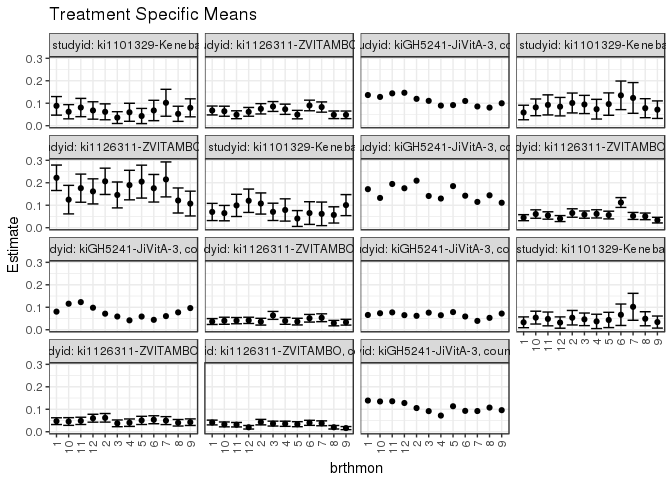

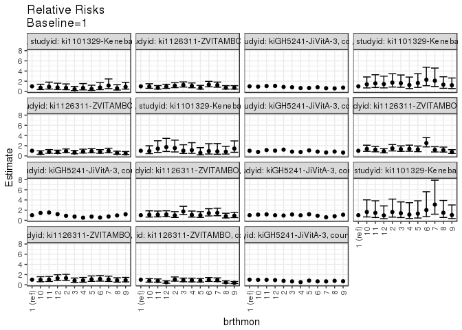

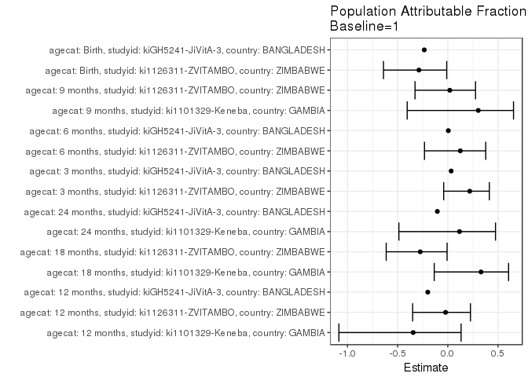

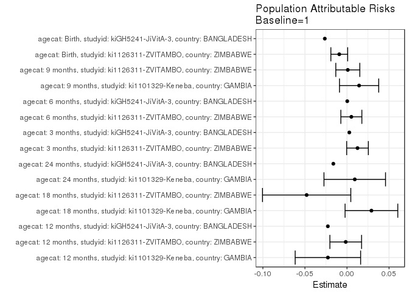

## Results Table

### Parameter: TSM

| agecat | studyid | country | intervention_level | baseline_level | estimate | ci_lower | ci_upper |
| --- | --- | --- | --- | --- | --- | --- | --- |
| Birth | ki1126311-ZVITAMBO | ZIMBABWE | 1 | NA | 0.0410754 | 0.0304449 | 0.0517060 |
| Birth | ki1126311-ZVITAMBO | ZIMBABWE | 2 | NA | 0.0428980 | 0.0306356 | 0.0551603 |
| Birth | ki1126311-ZVITAMBO | ZIMBABWE | 3 | NA | 0.0362381 | 0.0254787 | 0.0469976 |
| Birth | ki1126311-ZVITAMBO | ZIMBABWE | 4 | NA | 0.0353893 | 0.0238739 | 0.0469046 |
| Birth | ki1126311-ZVITAMBO | ZIMBABWE | 5 | NA | 0.0335306 | 0.0224501 | 0.0446111 |
| Birth | ki1126311-ZVITAMBO | ZIMBABWE | 6 | NA | 0.0396476 | 0.0282951 | 0.0510000 |
| Birth | ki1126311-ZVITAMBO | ZIMBABWE | 7 | NA | 0.0375107 | 0.0266366 | 0.0483847 |
| Birth | ki1126311-ZVITAMBO | ZIMBABWE | 8 | NA | 0.0199521 | 0.0122092 | 0.0276951 |
| Birth | ki1126311-ZVITAMBO | ZIMBABWE | 9 | NA | 0.0162162 | 0.0093368 | 0.0230957 |
| Birth | ki1126311-ZVITAMBO | ZIMBABWE | 10 | NA | 0.0327238 | 0.0219054 | 0.0435422 |
| Birth | ki1126311-ZVITAMBO | ZIMBABWE | 11 | NA | 0.0313825 | 0.0214301 | 0.0413349 |
| Birth | ki1126311-ZVITAMBO | ZIMBABWE | 12 | NA | 0.0199005 | 0.0120181 | 0.0277829 |
| Birth | kiGH5241-JiVitA-3 | BANGLADESH | 1 | NA | 0.1388286 | NA | NA |
| Birth | kiGH5241-JiVitA-3 | BANGLADESH | 2 | NA | 0.1054054 | NA | NA |
| Birth | kiGH5241-JiVitA-3 | BANGLADESH | 3 | NA | 0.0917127 | NA | NA |
| Birth | kiGH5241-JiVitA-3 | BANGLADESH | 4 | NA | 0.0719755 | NA | NA |
| Birth | kiGH5241-JiVitA-3 | BANGLADESH | 5 | NA | 0.1133603 | NA | NA |
| Birth | kiGH5241-JiVitA-3 | BANGLADESH | 6 | NA | 0.0928854 | NA | NA |
| Birth | kiGH5241-JiVitA-3 | BANGLADESH | 7 | NA | 0.0921305 | NA | NA |
| Birth | kiGH5241-JiVitA-3 | BANGLADESH | 8 | NA | 0.1074589 | NA | NA |
| Birth | kiGH5241-JiVitA-3 | BANGLADESH | 9 | NA | 0.0959752 | NA | NA |
| Birth | kiGH5241-JiVitA-3 | BANGLADESH | 10 | NA | 0.1347584 | NA | NA |
| Birth | kiGH5241-JiVitA-3 | BANGLADESH | 11 | NA | 0.1357013 | NA | NA |
| Birth | kiGH5241-JiVitA-3 | BANGLADESH | 12 | NA | 0.1279178 | NA | NA |
| 3 months | ki1126311-ZVITAMBO | ZIMBABWE | 1 | NA | 0.0447110 | 0.0313339 | 0.0580881 |
| 3 months | ki1126311-ZVITAMBO | ZIMBABWE | 2 | NA | 0.0654762 | 0.0467726 | 0.0841797 |
| 3 months | ki1126311-ZVITAMBO | ZIMBABWE | 3 | NA | 0.0584653 | 0.0424156 | 0.0745150 |
| 3 months | ki1126311-ZVITAMBO | ZIMBABWE | 4 | NA | 0.0616541 | 0.0433721 | 0.0799361 |
| 3 months | ki1126311-ZVITAMBO | ZIMBABWE | 5 | NA | 0.0563584 | 0.0391753 | 0.0735415 |
| 3 months | ki1126311-ZVITAMBO | ZIMBABWE | 6 | NA | 0.1122195 | 0.0903735 | 0.1340654 |

[output cut: 150 more lines]

### Parameter: E(Y)

| agecat | studyid | country | intervention_level | baseline_level | estimate | ci_lower | ci_upper |
| --- | --- | --- | --- | --- | --- | --- | --- |
| Birth | ki1126311-ZVITAMBO | ZIMBABWE | NA | NA | 0.0318872 | 0.0289588 | 0.0348156 |
| Birth | kiGH5241-JiVitA-3 | BANGLADESH | NA | NA | 0.1124564 | NA | NA |
| 3 months | ki1126311-ZVITAMBO | ZIMBABWE | NA | NA | 0.0572174 | 0.0524694 | 0.0619655 |
| 3 months | kiGH5241-JiVitA-3 | BANGLADESH | NA | NA | 0.0832995 | NA | NA |
| 6 months | ki1126311-ZVITAMBO | ZIMBABWE | NA | NA | 0.0417119 | 0.0374091 | 0.0460146 |
| 6 months | kiGH5241-JiVitA-3 | BANGLADESH | NA | NA | 0.0659935 | NA | NA |
| 9 months | ki1101329-Keneba | GAMBIA | NA | NA | 0.0474117 | 0.0382478 | 0.0565756 |
| 9 months | ki1126311-ZVITAMBO | ZIMBABWE | NA | NA | 0.0480782 | 0.0432917 | 0.0528646 |
| 12 months | ki1101329-Keneba | GAMBIA | NA | NA | 0.0657084 | 0.0547027 | 0.0767141 |
| 12 months | ki1126311-ZVITAMBO | ZIMBABWE | NA | NA | 0.0662320 | 0.0602985 | 0.0721656 |
| 12 months | kiGH5241-JiVitA-3 | BANGLADESH | NA | NA | 0.1137625 | NA | NA |
| 18 months | ki1101329-Keneba | GAMBIA | NA | NA | 0.0878835 | 0.0752259 | 0.1005411 |
| 18 months | ki1126311-ZVITAMBO | ZIMBABWE | NA | NA | 0.1742690 | 0.1562842 | 0.1922538 |
| 24 months | ki1101329-Keneba | GAMBIA | NA | NA | 0.0794203 | 0.0666566 | 0.0921840 |
| 24 months | kiGH5241-JiVitA-3 | BANGLADESH | NA | NA | 0.1553692 | NA | NA |

### Parameter: RR

| agecat | studyid | country | intervention_level | baseline_level | estimate | ci_lower | ci_upper |
| --- | --- | --- | --- | --- | --- | --- | --- |
| Birth | ki1126311-ZVITAMBO | ZIMBABWE | 1 | 1 | 1.0000000 | 1.0000000 | 1.0000000 |
| Birth | ki1126311-ZVITAMBO | ZIMBABWE | 2 | 1 | 1.0443713 | 0.7102141 | 1.5357500 |
| Birth | ki1126311-ZVITAMBO | ZIMBABWE | 3 | 1 | 0.8822339 | 0.5950136 | 1.3080989 |
| Birth | ki1126311-ZVITAMBO | ZIMBABWE | 4 | 1 | 0.8615682 | 0.5684934 | 1.3057314 |
| Birth | ki1126311-ZVITAMBO | ZIMBABWE | 5 | 1 | 0.8163170 | 0.5364963 | 1.2420839 |
| Birth | ki1126311-ZVITAMBO | ZIMBABWE | 6 | 1 | 0.9652383 | 0.6561645 | 1.4198953 |
| Birth | ki1126311-ZVITAMBO | ZIMBABWE | 7 | 1 | 0.9132140 | 0.6191579 | 1.3469259 |
| Birth | ki1126311-ZVITAMBO | ZIMBABWE | 8 | 1 | 0.4857433 | 0.3046676 | 0.7744394 |
| Birth | ki1126311-ZVITAMBO | ZIMBABWE | 9 | 1 | 0.3947912 | 0.2401857 | 0.6489149 |
| Birth | ki1126311-ZVITAMBO | ZIMBABWE | 10 | 1 | 0.7966751 | 0.5235305 | 1.2123290 |
| Birth | ki1126311-ZVITAMBO | ZIMBABWE | 11 | 1 | 0.7640219 | 0.5073820 | 1.1504733 |
| Birth | ki1126311-ZVITAMBO | ZIMBABWE | 12 | 1 | 0.4844867 | 0.3018540 | 0.7776187 |
| Birth | kiGH5241-JiVitA-3 | BANGLADESH | 1 | 1 | 1.0000000 | NA | NA |
| Birth | kiGH5241-JiVitA-3 | BANGLADESH | 2 | 1 | 0.7592483 | NA | NA |
| Birth | kiGH5241-JiVitA-3 | BANGLADESH | 3 | 1 | 0.6606181 | NA | NA |
| Birth | kiGH5241-JiVitA-3 | BANGLADESH | 4 | 1 | 0.5184485 | NA | NA |
| Birth | kiGH5241-JiVitA-3 | BANGLADESH | 5 | 1 | 0.8165486 | NA | NA |
| Birth | kiGH5241-JiVitA-3 | BANGLADESH | 6 | 1 | 0.6690650 | NA | NA |
| Birth | kiGH5241-JiVitA-3 | BANGLADESH | 7 | 1 | 0.6636276 | NA | NA |
| Birth | kiGH5241-JiVitA-3 | BANGLADESH | 8 | 1 | 0.7740400 | NA | NA |
| Birth | kiGH5241-JiVitA-3 | BANGLADESH | 9 | 1 | 0.6913216 | NA | NA |
| Birth | kiGH5241-JiVitA-3 | BANGLADESH | 10 | 1 | 0.9706813 | NA | NA |
| Birth | kiGH5241-JiVitA-3 | BANGLADESH | 11 | 1 | 0.9774732 | NA | NA |
| Birth | kiGH5241-JiVitA-3 | BANGLADESH | 12 | 1 | 0.9214081 | NA | NA |
| 3 months | ki1126311-ZVITAMBO | ZIMBABWE | 1 | 1 | 1.0000000 | 1.0000000 | 1.0000000 |
| 3 months | ki1126311-ZVITAMBO | ZIMBABWE | 2 | 1 | 1.4644309 | 0.9683213 | 2.2147173 |
| 3 months | ki1126311-ZVITAMBO | ZIMBABWE | 3 | 1 | 1.3076260 | 0.8712434 | 1.9625810 |
| 3 months | ki1126311-ZVITAMBO | ZIMBABWE | 4 | 1 | 1.3789474 | 0.9049117 | 2.1013054 |
| 3 months | ki1126311-ZVITAMBO | ZIMBABWE | 5 | 1 | 1.2605033 | 0.8222943 | 1.9322384 |
| 3 months | ki1126311-ZVITAMBO | ZIMBABWE | 6 | 1 | 2.5098838 | 1.7564391 | 3.5865274 |

[output cut: 150 more lines]

### Parameter: PAR

| agecat | studyid | country | intervention_level | baseline_level | estimate | ci_lower | ci_upper |
| --- | --- | --- | --- | --- | --- | --- | --- |
| Birth | ki1126311-ZVITAMBO | ZIMBABWE | 1 | NA | -0.0091882 | -0.0191733 | 0.0007968 |
| Birth | kiGH5241-JiVitA-3 | BANGLADESH | 1 | NA | -0.0263722 | NA | NA |
| 3 months | ki1126311-ZVITAMBO | ZIMBABWE | 1 | NA | 0.0125064 | -0.0003695 | 0.0253824 |
| 3 months | kiGH5241-JiVitA-3 | BANGLADESH | 1 | NA | 0.0027685 | NA | NA |
| 6 months | ki1126311-ZVITAMBO | ZIMBABWE | 1 | NA | 0.0051879 | -0.0073096 | 0.0176855 |
| 6 months | kiGH5241-JiVitA-3 | BANGLADESH | 1 | NA | 0.0003219 | NA | NA |
| 9 months | ki1101329-Keneba | GAMBIA | 1 | NA | 0.0143928 | -0.0089325 | 0.0377182 |
| 9 months | ki1126311-ZVITAMBO | ZIMBABWE | 1 | NA | 0.0009578 | -0.0133163 | 0.0152318 |
| 12 months | ki1101329-Keneba | GAMBIA | 1 | NA | -0.0226894 | -0.0616032 | 0.0162245 |
| 12 months | ki1126311-ZVITAMBO | ZIMBABWE | 1 | NA | -0.0015099 | -0.0203421 | 0.0173223 |
| 12 months | kiGH5241-JiVitA-3 | BANGLADESH | 1 | NA | -0.0227507 | NA | NA |
| 18 months | ki1101329-Keneba | GAMBIA | 1 | NA | 0.0290600 | -0.0022766 | 0.0603965 |
| 18 months | ki1126311-ZVITAMBO | ZIMBABWE | 1 | NA | -0.0479532 | -0.1004493 | 0.0045428 |
| 24 months | ki1101329-Keneba | GAMBIA | 1 | NA | 0.0092449 | -0.0273449 | 0.0458347 |
| 24 months | kiGH5241-JiVitA-3 | BANGLADESH | 1 | NA | -0.0162284 | NA | NA |

### Parameter: PAF

| agecat | studyid | country | intervention_level | baseline_level | estimate | ci_lower | ci_upper |
| --- | --- | --- | --- | --- | --- | --- | --- |
| Birth | ki1126311-ZVITAMBO | ZIMBABWE | 1 | NA | -0.2881478 | -0.6413201 | -0.0109696 |
| Birth | kiGH5241-JiVitA-3 | BANGLADESH | 1 | NA | -0.2345108 | NA | NA |
| 3 months | ki1126311-ZVITAMBO | ZIMBABWE | 1 | NA | 0.2185773 | -0.0413262 | 0.4136117 |
| 3 months | kiGH5241-JiVitA-3 | BANGLADESH | 1 | NA | 0.0332355 | NA | NA |
| 6 months | ki1126311-ZVITAMBO | ZIMBABWE | 1 | NA | 0.1243757 | -0.2325276 | 0.3779305 |
| 6 months | kiGH5241-JiVitA-3 | BANGLADESH | 1 | NA | 0.0048773 | NA | NA |
| 9 months | ki1101329-Keneba | GAMBIA | 1 | NA | 0.3035714 | -0.4048678 | 0.6547627 |
| 9 months | ki1126311-ZVITAMBO | ZIMBABWE | 1 | NA | 0.0199208 | -0.3268386 | 0.2760573 |
| 12 months | ki1101329-Keneba | GAMBIA | 1 | NA | -0.3453038 | -1.0857477 | 0.1322812 |
| 12 months | ki1126311-ZVITAMBO | ZIMBABWE | 1 | NA | -0.0227971 | -0.3505801 | 0.2254336 |
| 12 months | kiGH5241-JiVitA-3 | BANGLADESH | 1 | NA | -0.1999840 | NA | NA |
| 18 months | ki1101329-Keneba | GAMBIA | 1 | NA | 0.3306648 | -0.1355259 | 0.6054607 |
| 18 months | ki1126311-ZVITAMBO | ZIMBABWE | 1 | NA | -0.2751678 | -0.6141764 | -0.0073576 |
| 24 months | ki1101329-Keneba | GAMBIA | 1 | NA | 0.1164042 | -0.4877795 | 0.4752303 |
| 24 months | kiGH5241-JiVitA-3 | BANGLADESH | 1 | NA | -0.1044507 | NA | NA |